# Tutorial 1

## Tool for conducting reproducible research

- What is reproducible research?
- Keeping track of things *(version control - git/github)*
- Communicating your data *(RMarkdown - Rstudio)*

### PHSL4005: Introduction to Biostatistics

By: Peter Kamerman (view on [GitHub Pages](http://kamermanpr.github.io/phsl4005-introductory-biostats) )

### Science under threat

[figure not shown]

### Science under threat

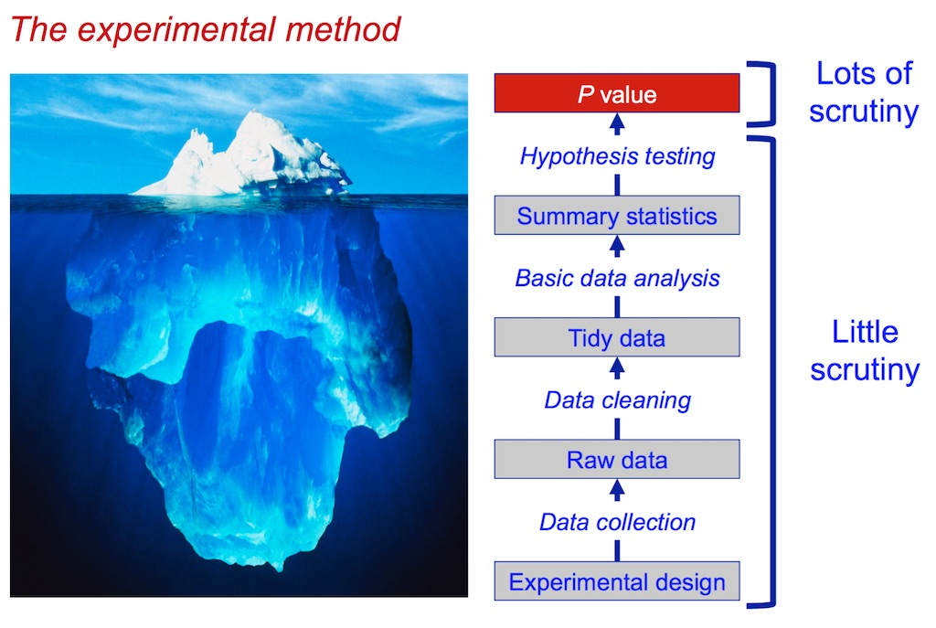

### Replicability

“Confirmation [replication] of findings by an independent group of investigators”

Replication is the ultimate standard for verifying research findings.

*…but it is very time-consuming and expensive exercise.*

### Reproducibility

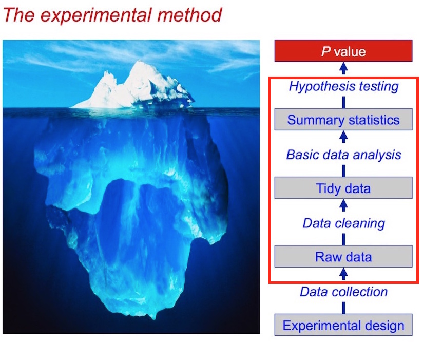

“The idea that data analyses, and more generally, scientific claims, are published with their data and software code so that others may verify the findings and build upon them.”

Roger Peng  
(Bloomberg School of Public Health)

### Basic needs for reproducible research

- **Access to the data**
  - Raw & analytical data
  - User-friendly format
- **Adequate documentation**
  - Code sheet
- **Ability to track data processing steps**
  - Version control
- **Literate (statistical) programming**
  - Machine readable statistical language
  - Human readable documentation
- **Dissemination**
  - tradiational vs non-tradiational
  - Sustainable/stable hosting infrastructure
  - Searchable / discoverable

### Ability to track analysis history

## Your typical workflow

1. Create
2. Save
3. Edit
4. Save edits
5. REPEAT steps 2 to 4

[figure not shown]

Source: [phdcomics.com](http://www.phdcomics.com/comics/archive/phd101212s.gif)

### Git - version control

## Your typical workflow

1. Create
2. Save
3. Edit
4. Save edits
5. REPEAT steps 2 to 4

Version control lets you **(and your collaborators)** know:

- When you *'saved'*
- Why you *'saved'*
- What changed

…and lets you share your changes with others

### Git: How does it work?

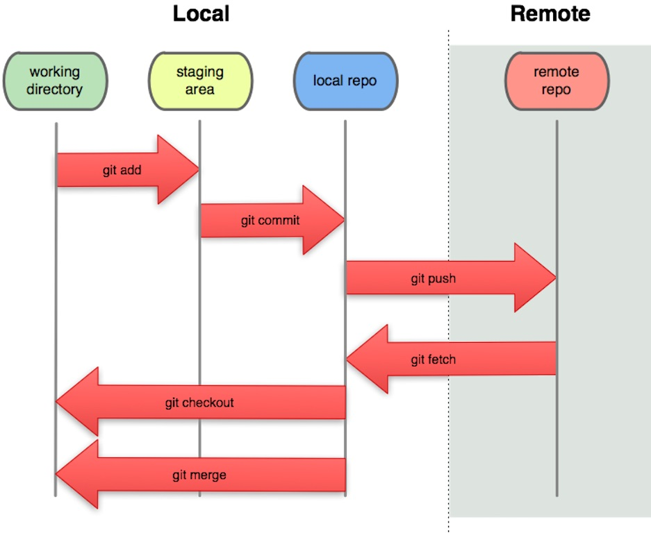

Source: [silverpeas.org](http://www.silverpeas.org/dev/collaboration.html)

### Git basics

Git is a very powerful tool, but you only need to learn the basics.

[figure not shown]

### In-class exercises

**Step 1:** Configure *git* after you first install the app.

```
$ git config --global user.name "YOUR NAME"
$ git config --global user.email "YOUR EMAIL"
```

**Step 2:** Navigate to a directory and intialise *git*.

```
$ cd <path/to/directory>
$ git init
```

**Alt Step 2:** Have *git* create and intialise an empty directory.

```
$ git init <path/to/directory>
```

### In-class exercises ...contd

**Step 3:** Add a *.gitignore* file to the directory, with file types you don't want tracked (e.g., [*.gitignore*](https://www.dropbox.com/s/81l46h93x9s4g8x/.gitignore?dl=0)).

**Step 4:** Check the status of the files in the directory.

```
$ git status
```

**Step 5:** Add all files to the *git* staging area.

```
$ git add .
```

### In-class exercises ...contd

**Step 6:** Commit all staged files for the first time *(take a snapshot)*

```
$ git commit -a -m 'First commit'
# -a: commit all staged files
# -m: you MUST provide a meaningful message
```

**Alt Step 6:** Commit selected files.

```
$ git commit <file-name> -m 'First commit'
```

Continuing working and saving files, and *commit* the changes when you are ready.

If your work generates new output files you want tracked, remember to *add* and *commit* those files.

### In-class exercises ...contd

**Undoing changes:** There are several methods in *git* to undo changes *(checkout, revert, reset)*. For most cases I recommend using *revert* because it is safe, and maintains the document history.

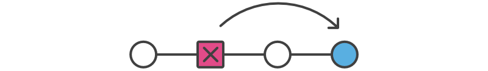

```
$ git revert <commit>
```

### In-class exercises ...contd

## Collaborating:

If you have generated something locally and want to *push* it to a remote repository.

**Step 1:** Open a new, empty respository in your *GitHub* account.  
**Step 2:** Copy the path to the new repository.  
**Step 3:** Add *remote*.

```
$ git remote add origin <http://path/to/repo.git>
```

**Step 4:** *Push* your files to the remote.

```
$ git push origin master
```

### In-class exercises ...contd

## Collaborating:

If you have forked someone elses *GitHub* repo, then you need to *clone* it to your local machine.

**Step 1:** Fork a *GitHub* repo.  
**Step 2:** Copy the path to the new repository.  
**Step 3:** *clone* the repo. This process automatically sets the *remote*

```
$ git clone <http://github.com/your-username/repo>
```

### In-class exercises ...contd

## Collaborating:

**Commited changes on the local machine:**

```
$ git push origin master
```

**Commited changes on the remote repo:**

```
$ git pull origin master
```

### In-class exercises ...lastly

**Sync a fork to its upstream source:**  
*GitHub* has lots of features, but no way of keeping your forked repos synced with the upstream source you forked them from. Here is the workaround.

```
$ git remote add upstream <http://path/to/upsteam/repo.git>
$ git fetch upstream
$ git checkout master
$ git merge upstream/master
$ git push origin master
```

### Communicating your data

## Ideal communication framework

- **Literate (statistical) programming**
- **Easy dissemination to remote repositories**

### Literate (statistical) programming

*R* (*tangle*) + [markdown + knitr (*weave*)] = RMarkdown

## Requires

- Statistical programming language to **tangle** machine-readable code
- Documentation language to **weave** human-readable documents

[figure not shown]

### Dissemination to remote repositories

**RStudio** + RMarkdown

[figure not shown]

### RStudio IDE

[figure not shown]

### RStudio IDE

**Interactive RStudio demo**

- Layout
- Global options
- Rscripts & RMarkdown documents
- Projects & *git* integration

### RMarkdown

The basics

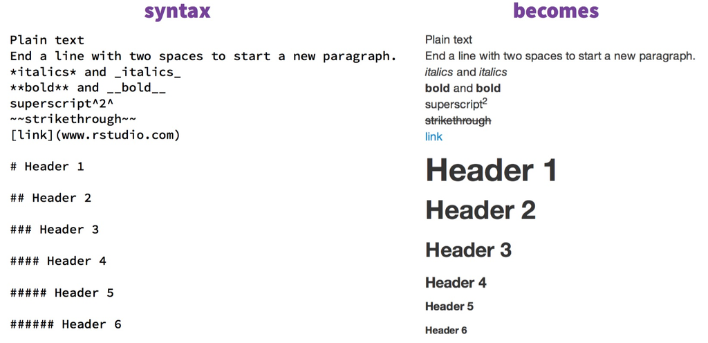

Source: [RStudio](https://www.rstudio.com/wp-content/uploads/2015/02/rmarkdown-cheatsheet.pdf)

### RMarkdown

The basics…contd

[figure not shown]

Source: [RStudio](https://www.rstudio.com/wp-content/uploads/2015/02/rmarkdown-cheatsheet.pdf)

### RMarkdown + knitr

*knitr*, by Yihui Xie, revolutionized literate programming in *R*.

*knitr* is very flexible, allowing you to **knit** together *'chunks'* of *R* code with *markdown / html / latex*, and output the resulting file to a variety different formats including:

- **.docx**
- **.pdf**
- **.html**
- **.md**

Complete documentation: [knitr](https://yihui.name/knitr/)

### RMarkdown + knitr

## Chunk options

In your *RMarkdown* document, you use regular markdown syntax for typing the documentation, and intersperse *'chunks'* or *R* code.

These sections of code can be **inline** or **blocks**

### RMarkdown + knitr

## Inline

```
The time is `r format(Sys.time(), '%H:%M')`, and I had better be getting to work.
```

The time is 11:34, and I had better be getting to work.

## Block

[output not shown]

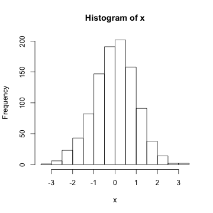

### RMarkdown + knitr

## Controlling chunk options

**Selected examples**

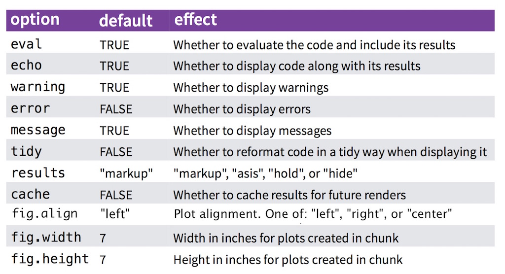

Complete documentation: [knitr](https://yihui.name/knitr/)

### RMarkdown + knitr

## Setting global chunk options

Example:

[figure not shown]

### Bringing it altogether

## Tutorial 1 assignment

Download the assignment and follow the instructions.  
[**[download]**](https://www.dropbox.com/s/h8paxnora4h3q5q/biostats-assignment-1.md?dl=1)

### Web resources

## Git / GitHub

- [git the simple guide](https://rogerdudler.github.io/git-guide/)
- [git cheat-sheet](https://ndpsoftware.com/git-cheatsheet.html#loc=workspace) *(interactive)*
- [git cheat-sheet](https://www.git-tower.com/blog/git-cheat-sheet/) *(static)*
- [GitHub Help](https://help.github.com)

## RMarkdown

- [Markdown](https://daringfireball.net/projects/markdown/basics) documentation
- [RMarkdown](https://rmarkdown.rstudio.com) documentation
- [RMarkdown cheat-sheet](https://www.rstudio.com/wp-content/uploads/2015/02/rmarkdown-cheatsheet.pdf)

### tl;dr

“Statistics are like bikinis. What they reveal is suggestive, but what they conceal is vital”

Aaron Levenstein  
(Baruch College, CUNY)

### tl;dr

“Statistics are like bikinis. What they reveal is suggestive, but what they conceal is vital”

Aaron Levenstein  
(Baruch College, CUNY)

“Think of reproducible research as trying to make the bikini a bit more transparent”